# R Notebook

# 14 Random variables

# 14.1 random variables

```r
beads <- rep( c("red", "blue"), times = c(2,3))
X <- ifelse(sample(beads, 1) == "blue", 1, 0)
```

```r
ifelse(sample(beads, 1) == "blue", 1, 0)
```

```
[1] 1
```

```r
ifelse(sample(beads, 1) == "blue", 1, 0)
```

```
[1] 0
```

```r
ifelse(sample(beads, 1) == "blue", 1, 0)
```

```
[1] 1
```

# 14.2 sampling models

We are going to define a random variable S that will represent the casino’s total winnings. Let’s start by constructing the urn. A roulette wheel has 18 red pockets, 18 black pockets and 2 green ones. So playing a color in one game of roulette is equivalent to drawing from this urn:

```r
color <- rep(c("Black", "Red", "Green"), c(18, 18, 2))
```

```r
n <- 1000
X <- sample(ifelse(color == "Red", -1, 1),  n, replace = TRUE)
X[1:10]
```

```
 [1]  1 -1  1  1  1  1 -1 -1 -1  1
```

```r
X <- sample(c(-1,1), n, replace = TRUE, prob=c(9/19, 10/19))
```

```r
S<-sum(X)
S
```

```
[1] 62
```

# 14.3 the probability distribution of a random variable

If you run the code above, you see that S changes every time. This is, of course, because S is a random variable.

```r
n <- 1000
B <- 10000
roulette_winnings <- function(n){
  X <- sample(c(-1,1), n, replace = TRUE, prob=c(9/19, 10/19))
  sum(X)
}
S <- replicate(B, roulette_winnings(n))
```

Now we can ask the following: in our simulations, how often did we get sums less than or equal to a?

```r
mean(S <= a)
```

```r
mean(S<0)
```

```
[1] 0.0449
```

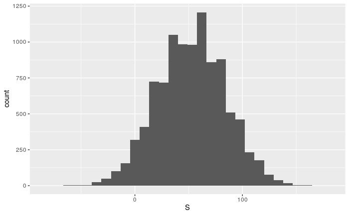

```r
library(tidyverse)
ggplot()+geom_histogram(aes(S))
```

```r
n <- 1000
pbinom(n/2, size = n, prob = 10/19)
```

```
[1] 0.05109794
```

```r
pbinom(n/2-1, size = n, prob = 10/19)
```

```
[1] 0.04479591
```

# 14.4 distributions versus probability distributions

we define the average and standard deviation. These are defined with a straightforward operation of the vector containing the list of numbers x:

```r
m <- sum(x)/length(x)
s <- sqrt(sum((x - m)^2) / length(x))
```

# 14.5 notation for random variables

In statistical textbooks, upper case letters are used to denote random variables and we follow this convention here. Lower case letters are used for observed values.

# 14.6 the expected value and standard error

The first important concept to learn is the expected value. In statistics books, it is common to use letter  
E like this: E[X]

```r
B <- 10^6
x <- sample(c(-1,1), B, replace = TRUE, prob=c(9/19, 10/19))
mean(x)
```

```
[1] 0.052392
```

If our draws are independent, then the standard error of the sum is given by the equation:

√number of draws × standard deviation of the numbers in the urn

```r
2 * sqrt(90)/19
```

```
[1] 0.998614
```

```r
n <- 1000
sqrt(n) * 2 * sqrt(90)/19
```

```
[1] 31.57895
```

# 14.6.1 population sd versus the sample sd

```r
library(dslabs)
x <- heights$height
m <- mean(x)
s <- sqrt(mean((x-m)^2))
```

```r
identical(s, sd(x))
```

```
[1] FALSE
```

```r
s-sd(x)
```

```
[1] -0.001942661
```

```r
n <- length(x)
s-sd(x)*sqrt((n-1) / n)
```

```
[1] 0
```

```r
sqrt(mean((x-m)^2))
```

```
[1] 4.076674
```

# 14.7 central limit theorem

The Central Limit Theorem (CLT) tells us that when the number of draws, also called the sample size, is large, the probability distribution of the sum of the independent draws is approximately normal.

```r
n <- 1000
B <- 10000
roulette_winnings <- function(n){
  X <- sample(c(-1,1), n, replace = TRUE, prob=c(9/19, 10/19))
  sum(X)
}
S <- replicate(B, roulette_winnings(n))
```

```r
n * (20-18)/38
```

```
[1] 52.63158
```

```r
sqrt(n) * 2 * sqrt(90)/19
```

```
[1] 31.57895
```

```r
mean(S)
```

```
[1] 52.0254
```

```r
sd(S)
```

```
[1] 31.39694
```

```r
mu <- n * (20-18)/38
se <-  sqrt(n) * 2 * sqrt(90)/19
pnorm(0,mu,se)
```

```
[1] 0.04779035
```

```r
mean(S<0)
```

```
[1] 0.0448
```

# 14.7.1 how large is large in the central limit theorem?

In the lottery, the chances of winning are less than 1 in a million. Thousands of people play so the number of draws is very large. Yet the number of winners, the sum of the draws, range between 0 and 4. This sum is certainly not well approximated by a normal distribution, so the CLT does not apply, even with the very large sample size. This is generally true when the probability of a success is very low. In these cases, the Poisson distribution is more appropriate.

# 14.8 statistical properties of averages

1. The expected value of the sum of random variables is the sum of each random variable’s expected value.
2. The expected value of a non-random constant times a random variable is the non-random constant times the expected value of a random variable.
3. The square of the standard error of the sum of independent random variables is the sum of the square of the standard error of each random variable.
4. The standard error of a non-random constant times a random variable is the non-random constant times the random variable’s standard error.
5. If X is a normally distributed random variable, then if a and b are non-random constants, aX+b is also a normally distributed random variable. All we are doing is changing the units of the random variable by multiplying by  
   a , then shifting the center by b .

# 14.9 law of large numbers

When n is very large, then the standard error is practically 0 and the average of the draws converges to the average of the urn. This is known in statistical textbooks as the law of large numbers or the law of averages.

# 14.9.1 misinterpreting law of averages

law of independence 생각

# 14.10 exercises

1. In American Roulette you can also bet on green. There are 18 reds, 18 blacks and 2 greens (0 and 00). What are the chances the green comes out?

2/38

```r
B<-10000
n<-1
x <- sample(c(17,-1), 1, prob = c(1/19, 18/19))
roulette_winnings <- function(n){
  x <- sample(c(17,-1), 1, prob = c(1/19, 18/19))

}
S<-replicate(B,roulette_winnings(n))
tab<-table(S)
prop.table(tab)
```

```
S
    -1     17
0.9463 0.0537
```

0.0537

4. Compute the standard error of X . 4.01934
5. Now create a random variable S that is the sum of your winnings after betting on green 1000 times. Hint: change the argument size and replace in your answer to question 2. Start your code by setting the seed to 1 with set.seed(1).

```r
set.seed(1)
B <- 1000
X <- sample(c(17,-1), B, replace=TRUE, prob = c(1/19, 18/19))
S <- sum(X)
S
```

```
[1] -10
```

6. What is the expected value of S ?

```r
B * (2/38 * 17 + 36/38 * -1)
```

```
[1] -52.63158
```

7.What is the standard error of S?

```r
sqrt(B) * abs((17 - -1))*sqrt(1/19*18/19)
```

```
[1] 127.1028
```

8. What is the probability that you end up winning money? Hint: use the CLT.

```r
m <- B * (1/19 * 17 + 18/19 * -1)
se <- sqrt(B) * abs((17 - -1))*sqrt(1/19*18/19)
1 - pnorm(0, m, se)
```

```
[1] 0.3394053
```

9.Create a Monte Carlo simulation that generates 1,000 outcomes of S . Compute the average and standard deviation of the resulting list to confirm the results of 6 and 7. Start your code by setting the seed to 1 with set.seed(1).

```r
set.seed(1)
simulate <- replicate(B,{
  X <- sample(c(17,-1), B, replace=TRUE, prob = c(1/19, 18/19))
  sum(X)
})
mean(simulate)
```

```
[1] -59.086
```

```r
sd(simulate)
```

```
[1] 125.672
```

10.Now check your answer to 8 using the Monte Carlo result.

```r
mean(simulate>0)
```

```
[1] 0.324
```

11. The Monte Carlo result and the CLT approximation are close, but not that close. What could account for this?

a.1,000 simulations is not enough. If we do more, they match. b.The CLT does not work as well when the probability of success is small. In this case, it was 1/19. If we make the number of roulette plays bigger, they will match better. c.The difference is within rounding error. d.The CLT only works for averages.

b

12.Now create a random variable Y that is your average winnings per bet after playing off your winnings after betting on green 1,000 times.

```r
X <- sample(c(17,-1), 1000, replace=TRUE, prob = c(1/19,18/19))
Y <- mean(X)
```

13. What is the expected value of Y ?

```r
1000 * (1/19 * 17 + 18/19 * -1)
```

```
[1] -52.63158
```

14.What is the standard error of Y ?

```r
sqrt(1000)*abs((17 - -1))*sqrt(1/19*18/19)
```

```
[1] 127.1028
```

15.What is the probability that you end up with winnings per game that are positive? Hint: use the CLT.

```r
m <- 1000 * (1/19 * 17 + 18/19 * -1)
se <- sqrt(1000)*abs((17 - -1))*sqrt(1/19*18/19)
1 - pnorm(0, m, se)
```

```
[1] 0.3394053
```

16.Create a Monte Carlo simulation that generates 2,500 outcomes of Y . Compute the average and standard deviation of the resulting list to confirm the results of 6 and 7. Start your code by setting the seed to 1 with set.seed(1).

```r
set.seed(1)
simulate <- replicate(2500,{
  Y <- sample(c(17,-1), 1000, replace=TRUE, prob = c(1/19, 18/19))
  mean(Y)
})
mean(simulate)
```

```
[1] -0.0543376
```

```r
sd(simulate)
```

```
[1] 0.1259509
```

17.Now check your answer to 8 using the Monte Carlo result.

```r
mean(simulate>0)
```

```
[1] 0.3372
```

18.The Monte Carlo result and the CLT approximation are now much closer. What could account for this?

a.We are now computing averages instead of sums. b.2,500 Monte Carlo simulations is not better than 1,000. c.The CLT works better when the sample size is larger. We increased from 1,000 to 2,500. d.It is not closer. The difference is within rounding error.

c

# 14.11 case study:the big short

# 14.11.1 interest rates explained with chance model

```r
n <- 1000
loss_per_foreclosure <- -200000
p <- 0.02
defaults <- sample( c(0,1), n, prob=c(1-p, p), replace = TRUE)
sum(defaults * loss_per_foreclosure)
```

```
[1] -4800000
```

```r
B <- 10000
losses <- replicate(B, {
    defaults <- sample( c(0,1), n, prob=c(1-p, p), replace = TRUE)
  sum(defaults * loss_per_foreclosure)
})
```

```r
n*(p*loss_per_foreclosure + (1-p)*0)
```

```
[1] -4e+06
```

```r
sqrt(n)*abs(loss_per_foreclosure)*sqrt(p*(1-p))
```

```
[1] 885437.7
```

```r
-loss_per_foreclosure*p/(1-p)
```

```
[1] 4081.633
```

```r
qnorm(0.01)
```

```
[1] -2.326348
```

```r
l <- loss_per_foreclosure
z <- qnorm(0.01)
x <- -l*( n*p - z*sqrt(n*p*(1-p)))/ ( n*(1-p) + z*sqrt(n*p*(1-p)))
x
```

```
[1] 6249.181
```

```r
loss_per_foreclosure*p + x*(1-p)
```

```
[1] 2124.198
```

```r
n*(loss_per_foreclosure*p + x*(1-p))
```

```
[1] 2124198
```

```r
B <- 100000
profit <- replicate(B, {
    draws <- sample( c(x, loss_per_foreclosure), n,
                        prob=c(1-p, p), replace = TRUE)
    sum(draws)
})
mean(profit)
```

```
[1] 2122614
```

```r
mean(profit<0)
```

```
[1] 0.01301
```

# 14.11.2 the big short

```r
p <- 0.04
r <- (- loss_per_foreclosure*p/(1-p)) / 180000
r
```

```
[1] 0.0462963
```

```r
r <- 0.05
x <- r*180000
loss_per_foreclosure*p + x * (1-p)
```

```
[1] 640
```

```r
z <- qnorm(0.01)
n <- ceiling((z^2*(x-l)^2*p*(1-p))/(l*p + x*(1-p))^2)
n
```

```
[1] 22163
```

```r
n*(loss_per_foreclosure*p + x * (1-p))
```

```
[1] 14184320
```

```r
p <- 0.04
x <- 0.05*180000
profit <- replicate(B, {
    draws <- sample( c(x, loss_per_foreclosure), n,
                        prob=c(1-p, p), replace = TRUE)
    sum(draws)
})
mean(profit)
```

```
[1] 14199813
```

```r
p <- 0.04
x <- 0.05*180000
profit <- replicate(B, {
    new_p <- 0.04 + sample(seq(-0.01, 0.01, length = 100), 1)
    draws <- sample( c(x, loss_per_foreclosure), n,
                        prob=c(1-new_p, new_p), replace = TRUE)
    sum(draws)
})
```

```r
mean(profit)
```

```
[1] 14271904
```

```r
mean(profit<0)
```

```
[1] 0.34639
```

```r
mean(profit < -10000000)
```

```
[1] 0.23889
```

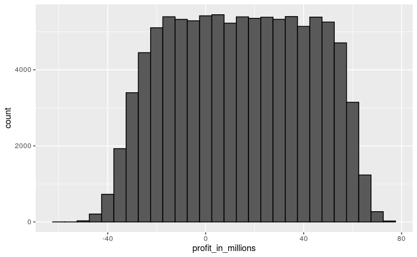

```r
data.frame(profit_in_millions=profit/10^6) %>%
  ggplot(aes(profit_in_millions)) +
  geom_histogram(color="black", binwidth = 5)
```

# 14.12 exercises

```r
n <- 10000
loss_per_foreclosure <- -200000
p <- 0.03
defaults <- sample(c(0,1), n, prob=c(1-p, p),replace=TRUE)
S <- sum(defaults * loss_per_foreclosure)
S
```

```
[1] -65800000
```

2.Run a Monte Carlo simulation with 10,000 outcomes for S . Make a histogram of the results.

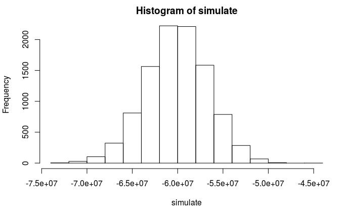

```r
simulate <- replicate(n, {
  p <- sample(c(0,1), n, prob=c(1-p, p),replace=TRUE)
  sum(p * loss_per_foreclosure)
})
hist(simulate)
```

3.What is the expected value of S ?

```r
n*(p*loss_per_foreclosure + (1-p)*0)
```

```
[1] -6e+07
```

4.What is the standard error of S ?

```r
sqrt(n) * abs(loss_per_foreclosure) * sqrt(p*(1-p))
```

```
[1] 3411744
```

5.Suppose we give out loans for $180,000. What should the interest rate be so that our expected value is 0?

```r
x <- -(loss_per_foreclosure*p) / (1 -p)
x / 180000
```

```
[1] 0.03436426
```

6.(Harder) What should the interest rate be so that the chance of losing money is 1 in 20? In math notation, what should the interest rate be so that Pr(S<0)=0.05 ?

```r
nor <- qnorm(0.05)
x <- -loss_per_foreclosure*( n*p - nor*sqrt(n*p*(1-p)))/ ( n*(1-p) + nor*sqrt(n*p*(1 -p)))
x / 180000
```

```
[1] 0.03768738
```

7. If the bank wants to minimize the probabilities of losing money, which of the following does not make interest rates go up?

a.A smaller pool of loans. b.A larger probability of default. c.A smaller required probability of losing money. d.The number of Monte Carlo simulations.

d